# Case Study Seven

## Minimum Financial Loss Prediction

#### David Grijalva, Nicole Norelli, & Mingyang Nick YU

#### 12/03/2021

**Abstract**  
The following deliverable focuses on building a predictive model with the goal of reducing a company's monetary loss due to incorrect predictions. In this case study, the team trained and explored 6 different predictive models to achieve the company's goal.

## 1. Introduction

This case study focused on correctly predicting each target class in order to prevent monetary losses. For each wrong classification of class 1, there is a monetary loss of 100 dollars. For each wrong classification of class 0, there is a monetary loss of 25 dollars. The goal of this case study is to reduce the overall financial loss produced by the model.

#### Logistic Regression

Logistic Regression is a linear classification model which outputs the probability of the target variable. In its core, it works similarly to a linear regresssion with the difference that it uses the sigmoid function to convert the target variable between zero and one. Similar to Multiple Linear Regression, Logistic Regression can utilize both categorical variables and numeric variables as predictors. For binary classification problems, Logistic Regression takes a two-part loss function. When the target 𝑦 is 1 loss is: −𝑦log(𝑝) , when the target is 0 loss is: (1−𝑦)log(1−𝑝) .

#### Sigmoid Function

$$ s= {\frac{1}{1+e^{-x}}} $$

#### Ridge Regularization (L2)

Ridge regularization, or L2, is utilized as a penalty term for Logistic Regression in Scikit-learn by default. The penalty for this is the squared coefficients multiplied by Lambda, which controls the strength of the penalty. Unlike L1 regularization, L2 does not provide feature selection. All features are penalized uniformly but will never reach zero. In general, L2 is the primary regularization method used to prevent overfitting the model.

**Penalty Term**  
$\lambda \sum\limits_{j=0}^k m_j ^2 $  
Where $\lambda $ is the strength of the penalty. If $\lambda=0 $ then there would be no penalty applied and the original coefficient would be returned.

#### RandomForest

A Random Forest is an ensemble statistical learning method composed of several decision trees (known as weak learners) for which each individual prediction is combined to make a final overall prediction. Random Forest uses the concept of bootstrap aggregation, also called bagging. In simple terms, bootstrap is a sampling method with replacement (it can select the same instance on multiple samples), meaning, it randomly samples a subset of the training dataset population. When an algorithm uses bagging, it simply means training a weak learner (Decision Tree) for each of the subsamples selected. Different from bagging, Random Forest randomly subsamples parameters to be considered at each split. This produces a forest of weak learners that are less correlated from one another, and usually generates better prediction results compared to predictions using bagging alone.

To understand how Random Forest works it is important to understand how Decision Trees work. Decisions Trees are a supervised method that can be used for regression or classification. The key concept is that for every feature available, the Decision Tree splits the data into two branches, and for each split, it measures its information gain. The algorithm recursively repeats this operation until the stopping criteria is met.

There are two main methods to measure information gain: Gini and Entropy.

##### Gini Impurity

Gini Impurity is a measurement of the probability of incorrect classification for a new data point. The lower the Gini impurity is the more information is gained.

$$ G = \sum \limits _{i=1} ^{C} P(i) \dot (1-P(i)) $$

##### Entropy

Entropy is a mathematical formula to measure randomness. The lower the Entropy is the more information is gained due to having less randomness.

$$ H(X) = -\sum \limits _{i=1} ^{n} P(x_{i}) log_{b} P(x_{i}) $$

#### XGBoost

XGBoost is a popular algorithm created by Tianqi Chen and released in 2016. This algorithm can be found on many production applications used by major companies. There are three key aspects that make XGBoost an effective learner:  
1) The use of boosting  
2) The use of gradients.  
3) L2 regularization

Similar to Random Forest, boosting is also an ensemble method that uses weak learners to generate a strong one. Unlike Random Forest, which generates multiple and uncorrelated weak learners, boosting is composed of rounds or iterations of weak learners. The unique part of boosting is that each round tries to improve on the previous prediction, and each iteration is sequential to previous iterations rather than in parallel (Random Forest). Each of the iterations learns from its previous errors by using the gradient of the loss function. Specifically, after the first iteration the weak learners are no longer optimizing for the dependent variable, but rather for the residuals. These weak learner iterations continue until the stopping criteria is met.

To account for the prediction errors, XGBoost uses an approximate loss function which can be used with first and second-order partial derivatives.

$$ J= \sum \limits _{i}l(p _{i}, y_{i}) + \sum \limits _{k} \Omega (f _{k}) $$

This first equation displays a general loss function calculating the residuals or difference between the dependent variable and the prediction.

$$ \Omega (f) = \gamma T + \frac{1}{2} \lambda \rvert\lvert w \rvert\rvert^2 $$

The second equation displays the penalty imposed to reduce complexity in the terminal leaves.

Another key feature of XGBoost is that it has L2 regularization by default. The penalty imposed by the L2 is the squared coefficients multiplied by Lambda, which controls the strength of the penalty. Unlike L1 regularization, L2 does not provide feature selection. All features are penalized uniformly but will never reach zero. In general, L2 is the primary regularization method used to prevent overfitting the model.

$$ \lambda \sum\limits_{j=0}^k m_j ^2 $$

Where $\lambda $ is the strength of the penalty. If $\lambda=0 $ then there would be no penalty applied.

#### Neural Network

Neural Networks are supervised machine learning models composed of multiple layers. The inspiration for neural networks came from the basic understanding of how a human brain works. A brain is composed of neurons, which receive signals from multiple sources. Once the combined signals meet a certain threshold, the neuron fires an electrical impulse, which is transmitted to the subsequent neurons to which it is connected.

In a neural network, perceptrons (or neurons) are designed to perform this function. Neural networks are comprised of multiple layers of neurons. The layers between the input and the output are called hidden layers. A number of neurons for each layer in the network is designated. In the first hidden layer, each neuron receives all of the input variables and calculates a regression with different weights ($w$) assigned to each variable ($x$). A bias term ($b$) is added, and the result of the regression equation is passed through an activation function (${\sigma}$).

$z = {\sigma}(w_i x_i + b)$

The activation function is chosen by the user, but is typically nonlinear, such as a sigmoid or Rectified Linear Unit (ReLU). This function performs the threshold activation one would see in a biological cell and adds nonlinearity to the model. The initial values for weights and bias terms are randomly assigned from a distribution which can be specified.

The outputs from the first hidden layer are then passed as inputs to the next hidden layer, and the process repeats. In a dense neural network, all the neurons in each layer are connected to all the neurons in the previous and subsequent layers. The final output layer matches the target, with one output for a regression target, one or two outputs for a binary classification, or the appropriate number of outputs for a multi-class classification.

A neural network is "trained" using an optimizer and a loss function. An appropriate loss function is chosen, depending on the type of problem. Typical loss functions include "BinaryCrossentropy", "SparseCategoricalCrossentropy", and "MeanSquaredError." An optimizer is also selected. Historically, stochastic gradient descent was often used as the default optimizer, but it is currently a slower choice. More modern optimizers include "adam" and "RMSprop." The loss is calculated, and the optimizer updates the weights of the neural network accordingly during the "backwards pass." This is the time-consuming portion of the training, with forward passes being relatively quick to provide predictions.

Because neural networks are typically used with large data sets, data is broken down into batches. Batch size (the number of points in the network at one time) is specified, as well as the number of epochs (number of passes through the entire data set). Early stopping criteria can also be established. This monitors the loss, and a "patience" threshold is set. If the loss value increases for more successive epochs than the specified patience value, early stopping is reached. The early stopping criteria helps to avoid overfitting the data.

An additional method to prevent overfitting and provide regularization to neural networks is the use of drop-out layers ([Tensorflow documentation](https://www.tensorflow.org/api_docs/python/tf/keras/layers/Dropout)). Using this method, a certain proportion of inputs are randomly set to zero at each specified step, and the inputs that were not set to zero are scaled up by 1/(1-rate) so the sum of all inputs stays the same.

#### Ensemble

An Ensemble model is a machine learning technique that combines the out of fold predictions of several well tuned base models and feeds them as predictors to the next level(s) model which provides the final prediction.

The architecture of this ensemble model consists of two levels or more. For the purpose of introduction, a two level structured is used. Level-1 (well tuned base models) can contain two or more predictive models. Each model will be used to calculate out of fold predictions for each data point on the training data. The models themselves are also fitted based on training data. These models can use any statistical method as long as each is consistent with either the classification or regression task. For this case study, Logistic Regression, Random Forrest, and XGBoost were chosen (each described in the sections above). Level-2 consists of a single model which takes input features of a combined array of all the level-1 model out of fold predictions and provides final prediction results. For this case study, the level-2 model of choice was a Logistic Regression. For classification tasks, out of fold prediction probability is preferred rather than direct results, as it allows the level-2 model to learn more details of out of fold predictions through level-1 models. To generate new predictions for the test data, it will first flow through level-1 models to generate prediction probabilities together in the same order as the training data, and then feed those probabilities through the trained level-2 to get test predictions.

## 2. Methods

#### EDA and Cleaning

There were 160,000 instances and 51 features (including the target variable) provided for this anonymous dataset. Initial inspection identified that feature "x37" required conversion from a categorical variable into a numerical variable. The function `remove_pattern_convert_float` helped achieve this by removing the dollar sign in front of the string and changing it into float64, which is the ideal data type for this variable. All features had a small percentage of missing data, and most of the missing data was between 0.01% and 0.02%.

#### Data Split, Pipeline and Helper Functions

In order to evaluate model performance more objectively, the entire data set was stratified split into an 80/20 train/test set. A random state was set to ensure reproducibility. Individual pipelines were created for categorical variables and numeric variables. This is due to different imputation and treatment requirements for these two categories. For `categorical_pipe` (categorical variable pipeline), the data was first imputed by SimpleImputer using the 'most_frequent' strategy, and then one hot encoded with unknown levels ignored during training. For `numeric_pipe` (numerical variable pipeline), the data was also imputed using SimpleImputer, but using the 'mean' strategy instead, and then scaled by MinMaxScaller into a range of 0-1. Both of the pipelines were transformed by ColumnTransformer during runtime as a pre-processing step for the further modeling pipeline.

As has been instructed by the company, **every incorrectly classified instance 1 will mean a loss of 100 dollars, and every incorrectly classified instance 0 will mean a loss of 25 dollars**. A few helper functions were created specifically for targeting the tasks given. `estimate_total_loss` function was used to calculate normalized total financial loss based on misclassification on the test data. This function takes in true labels as 'y_test' and predicted labels as 'pred'. It then calculates total loss with all test data given, specifically the total number of incorrectly predicted for class 1 is multiplied by 100 and total number of incorrectly predicted for class 0 is multiplied by 25. This total loss is then normalized based on the total number of instances in the test set. The resulting calculation is the normalized loss on the given amount of test data. In order words, the result is the average loss per instance of the test data. This means the smaller the average loss the better, and the objective was to find the best algorithm or best cut off for prediction probability that would minimize the average loss.

The `find_best_prob` function was used to find a suitable cut-off and lowest dollar loss with a given model or prediction probability of class 1 (with 1.0 indicating absolute confidence the prediction is class 1 and 0.0 is absolute confidence the prediction is class 0). The function scanned through class 1 prediction probability from 0.50 to 1.0 with increments of 0.005. It utilized the above `estimate_total_loss` function to find a cut off that provided the lowest average dollar loss and returned a tuple of the best cut off and lowest dollar loss. The reason for only scanning from 0.5 was because incorrect predictions of class 1 had higher finacial penalties, thus only the probability that would generate more confidence for class 1 needed to be explored. This function also handled neural network model prediction from Keras and direct probability prediction of both classes (with specific parameters set to True for individual scenarios).

The `plot_roc_curve_custom` was used to plot the receiver operating characteristic curve. `get_confusion_matrix` was used to print the confusion matrix on predictions for the given test set. `get_classification_report` was used to get a comprehensive classification report including Training accuracy, Test Accuracy, classification report on test set, and it reused `plot_roc_curve_custom` and `get_confusion_matrix` functions as part of the comprehensive report as well. `cv_common` and `cv_summary` were used to present GridSearchCV or RandomSearchCV results to view hyperparameter combinations in a straightforward manner. `plot_early_stop_rounds` was designed for plotting Neural Network Train/Test Loss vs. Epochs.

#### Logistic Regression - Model 1

Logistic Regression was utilized as a baseline model. A pipeline incorporating both the `preprocessing` pipeline and the LogisticRegression was created under the variable `pipeline_lr_m1`. GridSearchCV was utilized to test all parameter combinations in the grid, and StratifiedKFold was utilized for 10-fold cross validation to lower any issue with class imbalance. `roc_auc` (area under the curve) was utilized as the scoring metric to evaluate both classes more fairly during search and extract the best parameter set because area under the curve considers both the False Positive Rate of one class and the True Positive Rate of the other class. A bigger AUC value also correlates with lower average financial loss after tuning prediction probability. `class_weight` was adjusted to "balanced" to automatically adjust weights inversely proportional to class frequencies to help adjust target class imbalance. `random_state` was set for reproducibility and `max_iter` was set to 10,000 to allow the Logistic Regression algorithm to take more steps towards convergence. Other parameters tuned by GridSearchCV are displayed under the variable `params_lr`:

```python
params_lr = {
    "model__penalty": ["l2"],
    "model__C": [0.01, 0.1, 1, 10, 100],
    "model__solver": ["lbfgs","liblinear","saga"],
}
```

The best parameters found were C = 100, using 'liblinear' solver.

After the best hyperparameters were found for Logistic Regression, the `find_best_prob` function was then deployed to search for the best cut off for this model. Details will be reported under Results section.

#### Logistic Regression with interaction terms - Model 2

Logistic Regression was utilized as a primary model. A pipeline incorporating the `preprocessing` pipeline; the `interactions` pipeline, which utilized PolynomialFeatures supplied by SKLearn to create interaction terms for all existing features; the features were scaled by MinMaxScaler to 0-1 range; and the `model` pipeline LogisticRegression was created under the variable `pipeline_lr_m3`. GridSearchCV was utilized to test all parameter combinations in the grid, and StratifiedKFold was utilized for 10-fold cross validation to lower any issue with class imbalance. `roc_auc` (area under the curve) was utilized as the scoring metric to evaluate both classes more fairly during search and extract the best parameter set because area under the curve considers both the False Positive Rate of one class and the True Positive Rate of the other class. A bigger AUC value also correlates with lower average financial loss after tuning prediction probability. `class_weight` was adjusted to "balanced" to automatically adjust weights inversely proportional to class frequencies to help adjust target class imbalance. `random_state` was set for reproducibility and `max_iter` was set to 10,000 to allow the Logistic Regression algorithm to take more steps towards convergence. Other parameters tuned by GridSearchCV were the same as those in Model 1.

This particular model took an extremely long time to train with intensive memory and CPU requirements. On the machine it was trained, it took around 5 days 10 hours and 39 minutes. The best parameter combination found was for C=10, using 'liblinear' solver. After the best hyperparameters were found, the `find_best_prob` was deployed to find the best cut off and average monetary loss. Details will be presented under Results section.

#### Random Forest - Model 3

Random Forest was utilized as a baseline model. A pipeline incorporating both the `preprocessing` pipeline and the RandomForestClassifier was created under the variable `rf_pipeline`. RandomizedSearchCV was utilized due to the many different parameter combinations for tuning. Ten sets of different parameters were sampled from the defined grid without replacement, and StratifiedKFold was utilized for 10-fold cross validation due to the slight target class imbalance. `roc_auc` (area under the curve) was utilized as the scoring metric to evaluate both classes more fairly during search and extract the best parameter set because area under the curve considers both the False Positive Rate of one class and the True Positive Rate of the other class. A bigger AUC value also correlates with lower average financial loss after tuning prediction probability. `max_features` was set to "auto," which utilized the square root of the number of features. This has empirically generated good results for the Random Forest Classifier. `class_weight` was adjusted to "balanced" to automatically adjust weights inversely proportional to class frequencies to help adjust target class imbalance. Random state was set for reproducibility. Other parameters sampled by RandomizedSearchCV are displayed under the variable `params_rf`:

```python
params_rf = {
    "model__n_estimators": [250, 300, 350, 400],
    "model__max_features": ["auto"],
    "model__criterion": ['gini','entropy'],
    "model__max_depth":[10, 12, 15],
    "model__min_samples_split":[4, 7, 9],
    "model__class_weight":["balanced"]
}
```

Best parameter combination found was for 'n_estimators' = 350, 'criterion' = entropy, 'max_depth' = 15, 'min_samples_split' = 4. After the best hyperparameters were found, the `find_best_prob` was deployed to find the best cut off and average monetary loss. Details will be presented under Results section.

#### XGBoost - Model 4

```python
search_space = [
    {
        "model__learning_rate"    : [0.01, 0.1] ,
        "model__max_depth"        : [7, 8, 9],
        "model__subsample"        : [0.7, 0.9, 1],
        "model__gamma"            : [ 0.1, 0.4, 0.6],
     }
]
```

The best parameter set was found for 'learning_rate' = 0.1, 'max_depth' = 9 (maximum tree depth for base learner), 'subsample' = 1 (subsample ratio of the training instance), 'gamma' = 0.4 (minimum loss reduction required to make further partition on leaf node of tree). After the best hyperparameters were found, the `find_best_prob` was deployed to find the best cut off and average monetary loss. Details will be presented under Results section.

#### Neural Network - Model 5

The training and test data were first fit and transformed using the preprocessing pipeline. Sequential Deep Neural Network was created using Tensorflow and Keras. The Input Layer had 76 input variables after preprocessing transformation. Then it proceeded to a dense layer with 250 neurons followed by a dropout layer with 20% of neurons turned off during fit time. It then continued to another Dense layer of 200 neurons followed by a dropout layer of 0.2 percent and one last hidden dense layer of 100 followed by 0.2 percent of dropouts. The output layer was a single dense neuron with a 'sigmoid' activation for class 0 and class 1. The model was compiled with a 'binary_crossentropy' loss function with custom Adam optimizer of learning_rate = 0.001. It monitored both 'accuracy' as well as area under the curve metric.

The deep neural network used batch size of 1000 instances, and initial epochs of 2000. This does not slow the training time because the model monitors validation data at runtime, and when the validation loss stops improving for 10 consecutive epochs, the training will stop automatically. Figure 1 illustrates the train/test loss versus number of epochs. It can be observed that initially both training loss and test loss decrease quickly. Test loss stops improving at around 81 epochs. The model patiently waited for another 10 epochs for test loss to decrease further and the training stopped after validation loss failed to decreased further. The final training loss for train and test are roughly the same when the model stopped, and no overfitting of the training set has been discovered based on the loss vs. Epochs curve. The `find_best_prob` was deployed to find the best cut off and average monetary loss. Details will be presented under Results section.

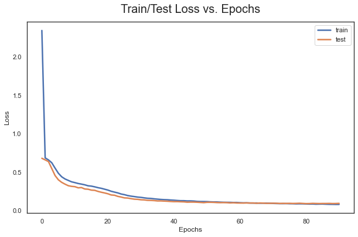

```python
plot_early_stop_rounds(model_loss)
```

Figure 1: Deep Neural Network Train/Test Loss vs. Epochs

#### Ensemble - Model 6

The final model attempted used an ensemble of three models explored previously. Logistic Regression, Random Forest Classifier and XGBoost Classifier. Each model was initialized with the best parameter combination discovered during Grid search or Random search. The `get_models` method initializied a list of models to be used under our ultimate ensemble model and it returned a list of level-1 prediction models to be used. The `fit_ensemble` method trained each level-1 model in the models list and used `cross_val_predict` to obtain out of fold prediction probability for each training instance using the provided number of cross validation. The out of fold prediction probability of both class 0 and class 1 for all models in the models list are stacked together to be used as the predictor for level-2, which uses LogisticRegression to again be fitted with given labels. `fit_ensemble` returns the level-2 Logistic Regression classifier to be used for prediction. `predict_ensemble` takes in a list of trained models (level-1) and trained level-2 model as well as test data. It goes through each model from the level-1 models list to get the prediction probability for test data to be stacked, and then uses the stacked predictive probabilities for level-2 logistic regression model prediction. Finally, it returns the predictive probability for both classes as the ultimate result. The `find_best_prob` was deployed to find the best cut off and average monetary loss. Details will be presented under Results section.

## 3. Results

Table 1 shows a comparison of the six different models attempted. The test AUC for the models ranged from 0.766 to 0.991, and accuracy scores on the test data ranged from 0.71 to 0.97. The model with the worst overall performance was the Logistic Regression (Model 1) without additional interaction terms. While it was the second fastest to train (at 5 minutes, 30 seconds), its performance was poor. Logistic Regression with Interactions (Model 2) had improved performance when compared with the straightforward Logistic Regression model, but the training time was very long, at over five days. Random Forest (Model 3) showed improved performance over the two logistic models, with a training time of 1 hour, 17 minutes. The top three performing models were XGBoost, Neural Network, and Ensemble. Each produced a test AUC of over 0.98, with Neural Network (Model 5) producing a slightly better test AUC in the shortest overall training time (1 minutes, 56 seconds).

| Model | Test AUC | Test Accuracy | Training Time |
| --- | --- | --- | --- |
| 1: Logistic Regression | 0.76618 | 0.71 | 5min 30s |
| 2: Logistic Regression with Interactions | 0.94129 | 0.87 | 5days 10h 39m 20s |
| 3: Random Forest | 0.96701 | 0.91 | 1h 17m |
| 4: XGBoost | 0.98450 | 0.95 | 4h 58m 8s |
| 5: Neural Network | 0.99161 | 0.97 | 1m 56s |
| 6: Ensemble | 0.9828 | 0.95 | 50min |

Table 1: Overall performance for each model

Table 2 details the precision and recall for each class in each of the six models. Precision for a class means among all the instances predicted by the model to be that class, how many are actually that class. Recall for a class means among all the instances that are in that class, how many can the model predict to be that class. Of course, these are the metrics for a default decision cut-off. Because penalties for misclassifications were different for each class, further exploration of optimal cut-off values was necessary.

| Model | Precision Class 0 | Recall Class 0 | Precision Class 1 | Recall Class 1 |
| --- | --- | --- | --- | --- |
| 1: Logistic Regression | 0.78 | 0.73 | 0.63 | 0.68 |
| 2: Logistic Regression with Interactions | 0.91 | 0.87 | 0.82 | 0.88 |
| 3: Random Forest | 0.92 | 0.92 | 0.89 | 0.89 |
| 4: XGBoost | 0.95 | 0.96 | 0.94 | 0.93 |
| 5: Neural Network | 0.97 | 0.98 | 0.96 | 0.96 |
| 6: Ensemble | 0.95 | 0.96 | 0.94 | 0.93 |

Table 2: Precision and Recall for each model

A prediction of class 1 that was not truly class 1 had a monetary penalty of 100 dollars, and a prediction of class 0 that was not truly class 0 had a monetary penalty of 25 dollars. Using the helper functions `find_best_prob` and `estimate_total_loss` explained previously, the optimal cut-off values for classification were examined for each model. A range of values was explored to find the cut-off that minimized financial penalties. Table 3 shows the average amount of loss per instance for each of the six models using the optimal cut-off value. These loss per instance amounts were calculated using the test data (32,000 instances) to give the most accurate estimates of performance on unseen data.

| Model | Average dollar loss per instance |
| --- | --- |
| 1: Logistic Regression | 9.6828125 |
| 2: Logistic Regression with Interactions | 5.690625 |
| 3: Random Forest | 4.06796875 |
| 4: XGBoost | 2.51484375 |
| 5: Neural Network | 1.41484375 |
| 6: Ensemble | 2.5703125 |

Table 3: Average financial loss using optimal cut-off value

The model with the lowest loss per instance was Model 5, the Neural Network. Figure 2 shows the confusion matrix for Model 5 under the best probability cut off. Predictions of class 1 that are not truly class 1 result in a loss of 100 dollars (198 *100 = 19,800), and predictions of class 0 that are not truly class 0 result in a loss of 25 dollars (1019* 25 = 25,475). Total loss for the test data would be 19,800 + 25,475 = 45,275, with an average loss per instance of 45,275 / 32,000 = $1.41.

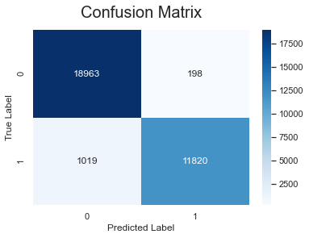

```python
y_hat_nn_m5_best_cutoff = (model.predict(X_test_nn)>best_cutoff_m5).astype("int32")
get_confusion_matrix(y_test,y_hat_nn_m5_best_cutoff)
```

Figure 2: Confusion Matrix for Model 5

## 4. Conclusion

Six total predictive models were explored to find the best option for minimizing financial loss. The hyperparameters for each model were tuned, and the tuned models were then examined to find the optimal prediction cut-off given the penalties for false positives and false negatives. Ultimately, Neural Network Model 5 is recommended for minimizing financial loss. It provides the lowest estimated financial penalties on average, with the best combination of false positives and false negatives. Model 5 produced an average loss of $1.41 per instance. Although it was not a consideration in model recommendation, Model 5 also had the fastest training time, at 1 minutes 56 seconds.

To further improve predictions, future models could explore more comprehensive ensemble methods. If additional information regarding the data set is made available, more targeted feature engineering could also be incoporated.

## Appendix - Code

```python
import pandas as pd
import numpy as np
import matplotlib.pyplot as plt
import seaborn as sns
%matplotlib inline

import joblib
import missingno as msno
import re

sns.set_theme()
# options
pd.set_option('display.max_columns', None)
# Using fixed os structure

from sklearn.preprocessing import OneHotEncoder, MinMaxScaler, PolynomialFeatures
from sklearn.impute import SimpleImputer
from sklearn.compose import ColumnTransformer
from sklearn.pipeline import Pipeline
from sklearn.model_selection import StratifiedKFold, train_test_split, RandomizedSearchCV, GridSearchCV
from sklearn.linear_model import LogisticRegression
from sklearn.ensemble import RandomForestClassifier
import xgboost as xgb
from sklearn.svm import SVC
from sklearn.metrics import classification_report,plot_confusion_matrix,plot_roc_curve, auc, roc_curve,confusion_matrix
from sklearn.linear_model import SGDClassifier

import os
cwd = os.getcwd()
d = os.path.dirname(cwd)
d

import tensorflow as tf
from tensorflow import keras
from tensorflow.keras.models import Sequential
from tensorflow.keras.layers import InputLayer, Dense, Activation, Dropout
from tensorflow.keras.callbacks import EarlyStopping

# Notebook options
pd.options.display.max_rows = 99999
pd.options.display.max_columns = 99999

import warnings
warnings.filterwarnings('ignore')
```

```python
file = cwd + "/final_project.csv"
data = pd.read_csv(file)
```

#### EDA

```python
data.shape
```

```
(160000, 51)
```

```python
data.info()
```

```
<class 'pandas.core.frame.DataFrame'>
RangeIndex: 160000 entries, 0 to 159999
Data columns (total 51 columns):
 #   Column  Non-Null Count   Dtype
---  ------  --------------   -----
 0   x0      159974 non-null  float64
 1   x1      159975 non-null  float64
 2   x2      159962 non-null  float64
 3   x3      159963 non-null  float64
 4   x4      159974 non-null  float64
 5   x5      159963 non-null  float64
 6   x6      159974 non-null  float64
 7   x7      159973 non-null  float64
 8   x8      159979 non-null  float64
 9   x9      159970 non-null  float64
```

[output cut: 43 more lines]

```python
data[data.select_dtypes(include="number").columns].describe()
```

|  | x0 | x1 | x2 | x3 | x4 | x5 | x6 | x7 | x8 | x9 | x10 | x11 | x12 | x13 | x14 | x15 | x16 | x17 | x18 | x19 | x20 | x21 | x22 | x23 | x25 | x26 | x27 | x28 | x31 | … |
| --- | --- | --- | --- | --- | --- | --- | --- | --- | --- | --- | --- | --- | --- | --- | --- | --- | --- | --- | --- | --- | --- | --- | --- | --- | --- | --- | --- | --- | --- | --- |
| count | 159974.000000 | 159975.000000 | 159962.000000 | 159963.000000 | 159974.000000 | 159963.000000 | 159974.000000 | 159973.000000 | 159979.000000 | 159970.000000 | 159957.000000 | 159970.000000 | 159964.000000 | 159969.000000 | 159966.000000 | 159965.000000 | 159974.000000 | 159973.000000 | 159960.000000 | 159965.000000 | 159962.000000 | 159971.000000 | 159973.000000 | 159953.000000 | 159978.000000 | 159964.000000 | 159970.000000 | 159965.000000 | 159961.000000 | … |
| mean | -0.001028 | 0.001358 | -1.150145 | -0.024637 | -0.000549 | 0.013582 | -1.670670 | -7.692795 | -0.030540 | 0.005462 | 0.002253 | 0.030232 | -1.334402 | 0.007669 | 0.008104 | 0.001215 | 0.006223 | 0.012040 | 0.012694 | 0.024555 | 0.299074 | -0.029137 | 0.008400 | 0.722028 | -0.000806 | -0.001066 | -0.004159 | 0.031543 | -0.005945 | … |
| std | 0.371137 | 6.340632 | 13.273480 | 8.065032 | 6.382293 | 7.670076 | 19.298665 | 30.542264 | 8.901185 | 6.355040 | 7.871429 | 8.769633 | 14.750990 | 8.953837 | 6.964097 | 3.271779 | 4.984065 | 7.569351 | 4.540714 | 7.595316 | 5.806203 | 9.409635 | 5.412010 | 14.909127 | 1.263656 | 0.843258 | 6.774047 | 14.439534 | 2.767508 | … |
| min | -1.592635 | -26.278302 | -59.394048 | -35.476594 | -28.467536 | -33.822988 | -86.354483 | -181.506976 | -37.691045 | -27.980659 | -36.306571 | -38.092869 | -64.197967 | -38.723514 | -30.905214 | -17.002359 | -26.042983 | -34.395898 | -20.198686 | -35.633396 | -26.677396 | -43.501854 | -23.644193 | -66.640341 | -6.364653 | -3.857484 | -32.003555 | -72.896705 | -12.289364 | … |
| 25% | -0.251641 | -4.260973 | -10.166536 | -5.454438 | -4.313118 | -5.148130 | -14.780146 | -27.324771 | -6.031058 | -4.260619 | -5.288196 | -5.903274 | -11.379492 | -6.029945 | -4.696755 | -2.207774 | -3.344027 | -5.071470 | -3.056131 | -5.101553 | -3.607789 | -6.361115 | -3.649766 | -9.268532 | -0.852784 | -0.567293 | -4.597919 | -9.702464 | -1.874206 | … |
| 50% | -0.002047 | 0.004813 | -1.340932 | -0.031408 | 0.000857 | 0.014118 | -1.948594 | -6.956789 | -0.016840 | 0.006045 | -0.018176 | 0.010941 | -1.624439 | -0.003473 | 0.002467 | 0.003535 | 0.012754 | 0.024541 | 0.015904 | 0.044703 | 0.433055 | -0.026385 | 0.011144 | 1.029609 | -0.003723 | -0.001501 | 0.037138 | 0.244210 | 0.002013 | … |
| 75% | 0.248532 | 4.284220 | 7.871676 | 5.445179 | 4.306660 | 5.190749 | 11.446931 | 12.217071 | 5.972349 | 4.305734 | 5.331573 | 5.935032 | 8.374524 | 6.041959 | 4.701299 | 2.211660 | 3.366853 | 5.101962 | 3.073002 | 5.164732 | 4.306566 | 6.316457 | 3.672678 | 11.028035 | 0.851765 | 0.567406 | 4.649773 | 9.936995 | 1.856369 | … |
| max | 1.600849 | 27.988178 | 63.545653 | 38.906025 | 26.247812 | 35.550110 | 92.390605 | 149.150634 | 39.049831 | 27.377842 | 37.945583 | 36.360443 | 73.279354 | 42.392177 | 32.546340 | 13.782559 | 21.961123 | 37.057048 | 19.652986 | 33.515550 | 27.814560 | 46.237503 | 24.863012 | 58.490500 | 5.314169 | 3.951652 | 28.645074 | 67.753845 | 12.279356 | … |

```python
data[data.select_dtypes(exclude="number").columns].describe()
```

|  | x24 | x29 | x30 | x32 | x37 |
| --- | --- | --- | --- | --- | --- |
| count | 159972 | 159970 | 159970 | 159969 | 159977 |
| unique | 3 | 12 | 5 | 12 | 129198 |
| top | asia | July | wednesday | 0.01% | $237.4 |
| freq | 138965 | 45569 | 101535 | 40767 | 6 |

```python
data['x24'].value_counts()
```

```
asia       138965
euorpe      16538
america      4469
Name: x24, dtype: int64
```

```python
data['x29'].value_counts()
```

```
July       45569
Jun        41329
Aug        29406
May        21939
sept.      10819
Apr         6761
Oct         2407
Mar         1231
Nov          337
Feb          140
Dev           23
January        9
Name: x29, dtype: int64
```

```python
data['x30'].value_counts()
```

```
wednesday    101535
thurday       29429
tuesday       27954
friday          564
monday          488
Name: x30, dtype: int64
```

```python
data['x32'].value_counts()
```

```
0.01%     40767
-0.01%    34094
0.0%      33923
-0.0%     30492
-0.02%     9924
0.02%      7987
-0.03%     1727
0.03%       855
-0.04%      138
0.04%        55
-0.05%        6
0.05%         1
Name: x32, dtype: int64
```

```python
data['x37'].value_counts()
```

```
$237.4       6
$72.42       6
$618.22      6
$-415.46     6
$-336.77     6
            ..
$-1997.05    1
$-1699.33    1
$-58.87      1
$518.87      1
$-986.62     1
Name: x37, Length: 129198, dtype: int64
```

```python
data['x37'][:5]
```

```
0     $1313.96
1     $1962.78
2      $430.47
3    $-2366.29
4     $-620.66
Name: x37, dtype: object
```

```python
# After observating x37, it should be converted to numeric variable
def remove_pattern_convert_float(pattern: str, original: str):
    if isinstance(original, str):
        original = original.lower()
        return float(re.sub(pattern, '', original ))
    else:
        return np.nan
```

```python
data['x37'] = data['x37'].apply(lambda x: remove_pattern_convert_float(r'[$]+', x))
```

```python
data['x37'][:5]
```

```
0    1313.96
1    1962.78
2     430.47
3   -2366.29
4    -620.66
Name: x37, dtype: float64
```

```python
data[data.select_dtypes(include="number").columns].describe()
```

|  | x0 | x1 | x2 | x3 | x4 | x5 | x6 | x7 | x8 | x9 | x10 | x11 | x12 | x13 | x14 | x15 | x16 | x17 | x18 | x19 | x20 | x21 | x22 | x23 | x25 | x26 | x27 | x28 | x31 | … |
| --- | --- | --- | --- | --- | --- | --- | --- | --- | --- | --- | --- | --- | --- | --- | --- | --- | --- | --- | --- | --- | --- | --- | --- | --- | --- | --- | --- | --- | --- | --- |
| count | 159974.000000 | 159975.000000 | 159962.000000 | 159963.000000 | 159974.000000 | 159963.000000 | 159974.000000 | 159973.000000 | 159979.000000 | 159970.000000 | 159957.000000 | 159970.000000 | 159964.000000 | 159969.000000 | 159966.000000 | 159965.000000 | 159974.000000 | 159973.000000 | 159960.000000 | 159965.000000 | 159962.000000 | 159971.000000 | 159973.000000 | 159953.000000 | 159978.000000 | 159964.000000 | 159970.000000 | 159965.000000 | 159961.000000 | … |
| mean | -0.001028 | 0.001358 | -1.150145 | -0.024637 | -0.000549 | 0.013582 | -1.670670 | -7.692795 | -0.030540 | 0.005462 | 0.002253 | 0.030232 | -1.334402 | 0.007669 | 0.008104 | 0.001215 | 0.006223 | 0.012040 | 0.012694 | 0.024555 | 0.299074 | -0.029137 | 0.008400 | 0.722028 | -0.000806 | -0.001066 | -0.004159 | 0.031543 | -0.005945 | … |
| std | 0.371137 | 6.340632 | 13.273480 | 8.065032 | 6.382293 | 7.670076 | 19.298665 | 30.542264 | 8.901185 | 6.355040 | 7.871429 | 8.769633 | 14.750990 | 8.953837 | 6.964097 | 3.271779 | 4.984065 | 7.569351 | 4.540714 | 7.595316 | 5.806203 | 9.409635 | 5.412010 | 14.909127 | 1.263656 | 0.843258 | 6.774047 | 14.439534 | 2.767508 | … |
| min | -1.592635 | -26.278302 | -59.394048 | -35.476594 | -28.467536 | -33.822988 | -86.354483 | -181.506976 | -37.691045 | -27.980659 | -36.306571 | -38.092869 | -64.197967 | -38.723514 | -30.905214 | -17.002359 | -26.042983 | -34.395898 | -20.198686 | -35.633396 | -26.677396 | -43.501854 | -23.644193 | -66.640341 | -6.364653 | -3.857484 | -32.003555 | -72.896705 | -12.289364 | … |
| 25% | -0.251641 | -4.260973 | -10.166536 | -5.454438 | -4.313118 | -5.148130 | -14.780146 | -27.324771 | -6.031058 | -4.260619 | -5.288196 | -5.903274 | -11.379492 | -6.029945 | -4.696755 | -2.207774 | -3.344027 | -5.071470 | -3.056131 | -5.101553 | -3.607789 | -6.361115 | -3.649766 | -9.268532 | -0.852784 | -0.567293 | -4.597919 | -9.702464 | -1.874206 | … |
| 50% | -0.002047 | 0.004813 | -1.340932 | -0.031408 | 0.000857 | 0.014118 | -1.948594 | -6.956789 | -0.016840 | 0.006045 | -0.018176 | 0.010941 | -1.624439 | -0.003473 | 0.002467 | 0.003535 | 0.012754 | 0.024541 | 0.015904 | 0.044703 | 0.433055 | -0.026385 | 0.011144 | 1.029609 | -0.003723 | -0.001501 | 0.037138 | 0.244210 | 0.002013 | … |
| 75% | 0.248532 | 4.284220 | 7.871676 | 5.445179 | 4.306660 | 5.190749 | 11.446931 | 12.217071 | 5.972349 | 4.305734 | 5.331573 | 5.935032 | 8.374524 | 6.041959 | 4.701299 | 2.211660 | 3.366853 | 5.101962 | 3.073002 | 5.164732 | 4.306566 | 6.316457 | 3.672678 | 11.028035 | 0.851765 | 0.567406 | 4.649773 | 9.936995 | 1.856369 | … |
| max | 1.600849 | 27.988178 | 63.545653 | 38.906025 | 26.247812 | 35.550110 | 92.390605 | 149.150634 | 39.049831 | 27.377842 | 37.945583 | 36.360443 | 73.279354 | 42.392177 | 32.546340 | 13.782559 | 21.961123 | 37.057048 | 19.652986 | 33.515550 | 27.814560 | 46.237503 | 24.863012 | 58.490500 | 5.314169 | 3.951652 | 28.645074 | 67.753845 | 12.279356 | … |

```python
data.y.value_counts()
```

```
0    95803
1    64197
Name: y, dtype: int64
```

```python
# class_weight = 'balanced' would result in following weight distribution
balanced_weight = data.shape[0]/ (2* np.bincount(data.y))
```

```python
balanced_weight
```

```
array([0.83504692, 1.24616415])
```

```python
# Identify attributes missing over 15% of values
columns_missing_rate = 100*((data.isna()).sum(axis = 0) / len(data))
columns_missing_rate = pd.DataFrame(columns_missing_rate)
columns_missing_rate = columns_missing_rate.reset_index()
columns_missing_rate.columns = ['name','rate']
print("     Initial Missing Data Inspection with all Attributes In     \n")
print('{:45s} {:4s}%'.format("Variable Name:","Missing Percentage"))
print("________________________________________________________________")
for index, row in columns_missing_rate.iterrows():
    if row['rate'] > 0:
        print(' {:45s} {:4s}%'.format(row['name'],str(np.round(row['rate'],4))))
```

```
     Initial Missing Data Inspection with all Attributes In

Variable Name:                                Missing Percentage%
________________________________________________________________
 x0                                            0.0162%
 x1                                            0.0156%
 x2                                            0.0238%
 x3                                            0.0231%
 x4                                            0.0162%
 x5                                            0.0231%
 x6                                            0.0162%
 x7                                            0.0169%
 x8                                            0.0131%
 x9                                            0.0188%
 x10                                           0.0269%
 x11                                           0.0188%
 x12                                           0.0225%
 x13                                           0.0194%
 x14                                           0.0212%
 x15                                           0.0219%
 x16                                           0.0162%
 x17                                           0.0169%
 x18                                           0.025%
 x19                                           0.0219%
 x20                                           0.0238%
 x21                                           0.0181%
 x22                                           0.0169%
 x23                                           0.0294%
 x24                                           0.0175%
 x25                                           0.0138%
 x26                                           0.0225%
 x27                                           0.0188%
 x28                                           0.0219%
 x29                                           0.0188%
 x30                                           0.0188%
 x31                                           0.0244%
 x32                                           0.0194%
 x33                                           0.0256%
 x34                                           0.0256%
 x35                                           0.0188%
 x36                                           0.0169%
 x37                                           0.0144%
 x38                                           0.0194%
 x39                                           0.0144%
 x40                                           0.0225%
 x41                                           0.025%
 x42                                           0.0162%
 x43                                           0.0231%
 x44                                           0.025%
 x45                                           0.0181%
 x46                                           0.0194%
 x47                                           0.0231%
 x48                                           0.02%
 x49                                           0.02%
```

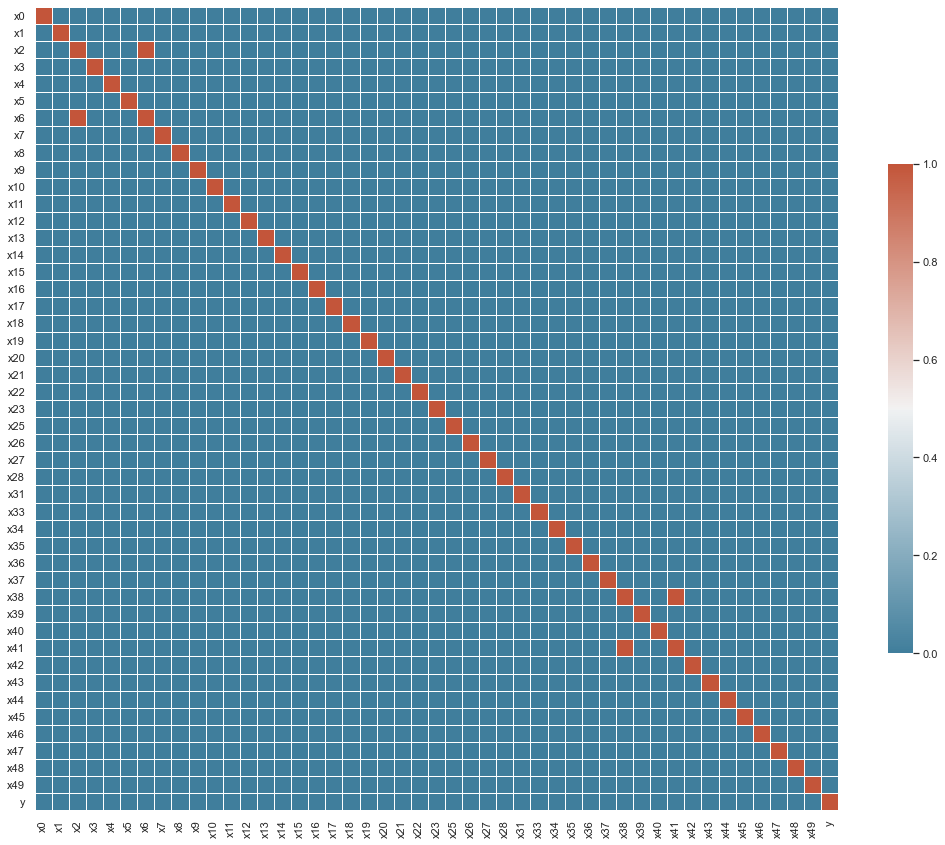

```python
# Look at Correlation over 0.999
corr1 = data.corr().abs()
# See resource below graph
upper_tri = corr1.where(np.triu(np.ones(corr1.shape),k=1).astype(np.bool))
sns.set_theme(style="white")
plt.subplots(figsize=(18,18))
cmap = sns.diverging_palette(230, 20, as_cmap=True)
sns.heatmap(corr1>0.999, cmap=cmap, vmax=1, center=0.5,
            square=True, linewidths=.5, cbar_kws={"shrink": .5})
```

```python
# Reorder the attribute name from less missing data to more missing data
# This is to make sure when deleting correlation > 0.999, the column with more missing data is deleted
missing_attribute_rank = list(columns_missing_rate.sort_values('rate',ascending=True)['name'])[1:]
```

```python
missing_attribute_rank.append('y')
print(missing_attribute_rank)
```

```
['x8', 'x25', 'x37', 'x39', 'x1', 'x0', 'x16', 'x42', 'x4', 'x6', 'x17', 'x36', 'x22', 'x7', 'x24', 'x21', 'x45', 'x30', 'x29', 'x27', 'x9', 'x11', 'x35', 'x38', 'x13', 'x46', 'x32', 'x48', 'x49', 'x14', 'x19', 'x15', 'x28', 'x40', 'x26', 'x12', 'x43', 'x47', 'x5', 'x3', 'x2', 'x20', 'x31', 'x41', '…
```

```python
data = data[missing_attribute_rank]
```

```python
# Check for correlation greater than 0.999
# correlation greater than 0.999 columns are too high in correlation of existing columns
to_drop = [column for column in upper_tri.columns if any(upper_tri[column] > 0.999)]
print(to_drop)
```

```
['x6', 'x41']
```

```python
# Dropping variables that have correlation over 0.999 compared to other variables
data.drop(to_drop, axis=1, inplace=True)
```

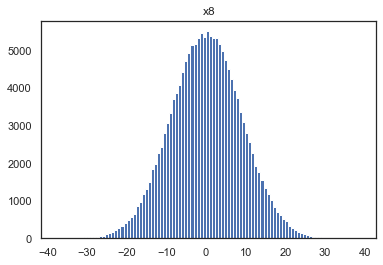

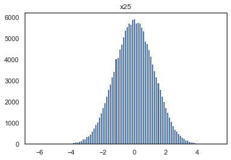

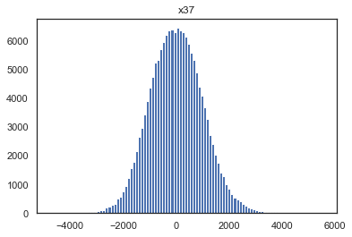

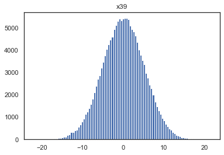

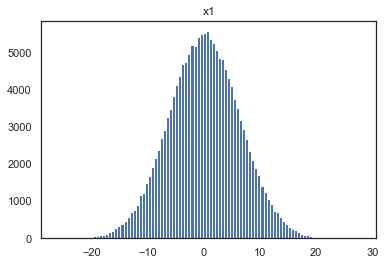

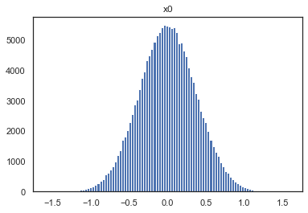

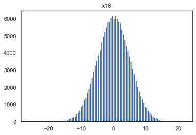

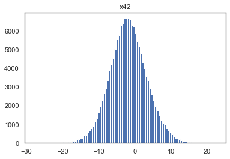

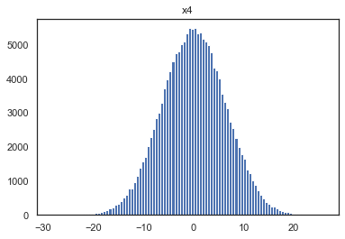

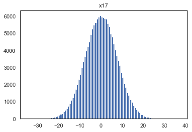

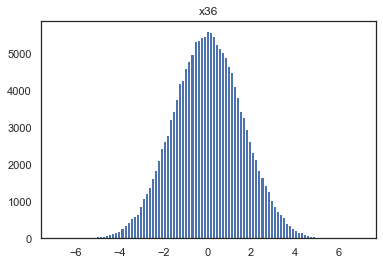

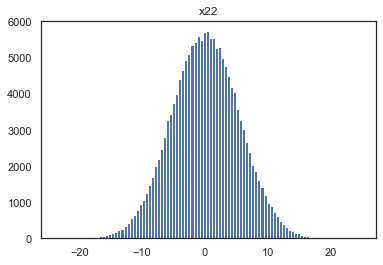

[33 more figures not shown]

```python
for i in data[data.select_dtypes(include="number").columns]:
    plt.hist(data[str(i)],bins=100)
    plt.title(str(i))
    plt.show()
```

#### Helper Functions

```python
X, y = data.drop(['y'],inplace=False,axis=1),data['y']
```

```python
categorical_col = X.select_dtypes(exclude="number").columns
numeric_col = X.select_dtypes(include="number").columns
```

```python
categorical_col
```

```
Index(['x24', 'x30', 'x29', 'x32'], dtype='object')
```

```python
numeric_col
```

```
Index(['x8', 'x25', 'x37', 'x39', 'x1', 'x0', 'x16', 'x42', 'x4', 'x17', 'x36',
       'x22', 'x7', 'x21', 'x45', 'x27', 'x9', 'x11', 'x35', 'x38', 'x13',
       'x46', 'x48', 'x49', 'x14', 'x19', 'x15', 'x28', 'x40', 'x26', 'x12',
       'x43', 'x47', 'x5', 'x3', 'x2', 'x20', 'x31', 'x18', 'x44', 'x33',
       'x34', 'x10', 'x23'],
      dtype='object')
```

```python
X_train, X_test, y_train, y_test = train_test_split(X, y,
                                                    test_size=0.20,
                                                    shuffle=True,
                                                    random_state=43,
                                                    stratify=y)
```

```python
X_train.head()
```

|  | x8 | x25 | x37 | x39 | x1 | x0 | x16 | x42 | x4 | x17 | x36 | x22 | x7 | x24 | x21 | x45 | x30 | x29 | x27 | x9 | x11 | x35 | x38 | x13 | x46 | x32 | x48 | x49 | x14 | … |
| --- | --- | --- | --- | --- | --- | --- | --- | --- | --- | --- | --- | --- | --- | --- | --- | --- | --- | --- | --- | --- | --- | --- | --- | --- | --- | --- | --- | --- | --- | --- |
| 32711 | 4.818294 | -0.751511 | -132.29 | 9.966825 | 0.393536 | -0.059149 | -1.270420 | -5.057279 | 4.136637 | 12.662353 | -1.527146 | -0.781457 | -10.050884 | asia | 2.462796 | -0.469746 | wednesday | Aug | -2.775357 | 0.880420 | -8.474544 | -2.117318 | 12.242264 | -5.441624 | -32.900235 | 0.01% | -1.254689 | 2.671931 | -6.074332 | … |
| 62711 | -5.491184 | 0.892447 | 155.71 | -4.571298 | -4.042493 | 0.572211 | 1.641904 | -11.588531 | -5.917686 | -17.663102 | 0.148461 | -1.157863 | -44.296829 | asia | -12.821612 | -0.491196 | tuesday | July | 0.463945 | -0.250551 | -0.676869 | 0.559639 | 8.653153 | 5.157350 | -3.807333 | -0.01% | 0.384543 | 7.070225 | 1.492781 | … |
| 159037 | 6.902716 | 1.795740 | -1077.95 | 4.800013 | 6.087087 | -0.580698 | 1.058950 | -6.060115 | -12.750003 | 4.523880 | -1.169425 | 1.285890 | 14.915669 | asia | -4.341017 | 0.642401 | wednesday | Jun | 4.252287 | -13.667932 | 10.884433 | 0.180583 | -20.157262 | 13.402536 | -56.673607 | -0.03% | 2.219874 | -11.629406 | 14.634137 | … |
| 104341 | -9.284466 | -0.075856 | 127.52 | -12.233423 | -2.697721 | 0.653991 | -5.892418 | 1.728180 | 6.247579 | -2.400305 | -0.069298 | 1.629688 | -12.137784 | asia | 9.409020 | 0.887573 | tuesday | July | 8.644166 | 4.597458 | 5.793557 | -2.454892 | 4.911760 | -18.633660 | 6.951384 | -0.0% | 3.654629 | -3.073061 | -6.267509 | … |
| 140913 | 2.209400 | 0.459428 | -82.85 | -4.669299 | 3.557623 | 0.149118 | 2.149834 | 0.474515 | -8.285954 | -4.488046 | 0.343159 | -9.314974 | -8.491626 | asia | -2.324015 | -0.051526 | tuesday | Jun | -2.453705 | 5.436926 | 4.733421 | 4.245784 | 6.587006 | -9.067905 | -15.017548 | -0.0% | 2.582283 | 3.545158 | -15.762276 | … |

#### Helper Function Models

```python
def get_acc_score(model, x, y):
    return model.score(x, y)

def plot_roc_curve_custom(x_test, y_test, model, nn_model = False, probability=False):
    if not nn_model:
        if probability:
            fpr, tpr, _ = roc_curve(y_test, model[:,1])
        else:
            fpr, tpr, _ = roc_curve(y_test, model.predict_proba(x_test)[:,1])
    else:
        fpr, tpr, _ = roc_curve(y_test, model.predict(x_test))
    roc_auc = auc(fpr, tpr)
    plt.plot(fpr, tpr, color='darkorange', label='Randomized Search CV (AUC = ' + str(round(roc_auc, 5)) + ')')
    plt.plot([0, 1], [0, 1], color='navy', lw=2, linestyle='--')
    plt.legend(loc='lower right')
    plt.ylabel('True Positive Rate')
    plt.xlabel('False Positive Rate')
    plt.title('Receiver operating characteristic',fontdict={'fontsize':20},pad=15)
    plt.show()

def get_confusion_matrix(y, yhat,mat_title="Confusion Matrix"):
    x_axis_labels = ['0','1']
    y_axis_labels = ['0','1']
    cm_n = confusion_matrix(y, yhat)
    ax = sns.heatmap(cm_n,cmap='Blues',annot=True,fmt='2d',xticklabels=x_axis_labels, yticklabels=y_axis_labels)
    ax.set(xlabel='Predicted Label', ylabel='True Label')
    ax.set_title(mat_title,fontdict={'fontsize':20},pad=15)
    plt.show()

def get_classification_report(x_train, y_train, x_test, y_test, pred, model, nn_model=False):
    """
    This function is used to get comprehensive classification report:
    Training Accuracy, Test Accuracy, print classification_report
    plot confusion matrix, and plot roc curve.
    """
    if not nn_model:
        print(f"Train accuracy: {get_acc_score(model, x_train, y_train):,.5f}")
    print("Test result:")
    print(f"Normalized Total Dollar Loss on Test Data {estimate_total_loss(y_test, pred):,.5f}\n")
    print(classification_report(y_test,pred))
    if not nn_model:
        fpr, tpr, thresholds = roc_curve(y_test, model.predict_proba(x_test)[:,1], pos_label=1)
    else:
        fpr, tpr, thresholds = roc_curve(y_test, model.predict(x_test), pos_label=1)
    print(f"Test AUC: {auc(fpr, tpr):,.5f}")
    plot_roc_curve_custom(x_test, y_test, model, nn_model=nn_model)
    if not nn_model:
        plot_confusion_matrix(model, x_test, y_test,colorbar=False)
        plt.grid(False)
    else:
        get_confusion_matrix(y_test, pred)

#     plot_roc_curve(model, x_test,y_test, response_method="predict_proba")


cv = StratifiedKFold(n_splits=10, shuffle=True, random_state=1)
verbose = 15

def cv_common(df, columns):
    cv_result_summary = df[columns]
    cv_result_summary.index  = np.arange(1,len(cv_result_summary)+1)
    cv_result_summary = cv_result_summary.reset_index()
    return cv_result_summary


def cv_summary(estimator, columns):
    df = pd.DataFrame(estimator.cv_results_)
    cv_result_summary = cv_common(df, columns)
    cv_result_summary = cv_result_summary.rename(columns = {
        "index": "param_combination",
        "mean_test_score": "mean_validation_score",
        "rank_test_score": "rank_validation_score"
    })
    return cv_result_summary

# Calculate Normalized Total Loss in Dollars
def estimate_total_loss(y_test, pred):
    """
    This function is used to calculate normalized total financial loss based on misclassification.
    """
    cm = confusion_matrix(y_test,pred)
    predict_0_wrong_d = cm[1,0]*25
    predict_1_wrong_d = cm[0,1]*100
    return (predict_1_wrong_d+predict_0_wrong_d)/np.sum(cm)

# Find best probability and cut off for given model
def find_best_prob(model, X_test, y_test, nn_model = False, probability=False):
    """
    This function use 0.005 increments to find best cut off among 0.01 to 0.5 probability range based
    on best_dollar_loss calculated using estimate_total_loss above.
    """
    best_dollar_loss = 100
    best_cut_off = 0.5
    for i in np.arange(0.5,1,0.005):
        if not nn_model:
            if probability:
                y_hat = (model[:,1] > i).astype('int32')
            else:
                y_hat = (model.predict_proba(X_test)[:,1]>i).astype("int32")
        else:
            y_hat = (model.predict(X_test)>i).astype("int32")
        if best_dollar_loss > estimate_total_loss(y_test, y_hat):
            best_dollar_loss = estimate_total_loss(y_test, y_hat)
            best_cut_off = i
    return best_cut_off, best_dollar_loss

def plot_early_stop_rounds(model_loss):
    plt.subplots(figsize=(10,6))
    plt.plot(model_loss['loss'],lw=2.5, label='train')
    plt.plot(model_loss['val_loss'],lw=2.5, label = 'test')
    plt.title('Train/Test Loss vs. Epochs',fontdict={'fontsize':20},pad=15)
    plt.ylabel('Loss')
    plt.xlabel('Epochs')
    plt.legend()
    plt.show()
```

```python
# Define preprocessing for columns
categorical_pipe = Pipeline(steps=[("cat_impute", SimpleImputer(missing_values=np.nan, strategy='most_frequent')),
                                     ('cat', OneHotEncoder(handle_unknown='ignore'))])
numeric_pipe = Pipeline(steps=[('numeric_impute', SimpleImputer(missing_values=np.nan, strategy='mean')),
                                     ('scale',MinMaxScaler())])
```

```python
t_slr_impute = [
    ('cat', categorical_pipe, categorical_col),

    ('scale', numeric_pipe, numeric_col)]
col_transform = ColumnTransformer(t_slr_impute)
```

#### Logistic Regression - Model 1

```python
params_lr = {
    "model__penalty": ["l2"],
    "model__C": [0.01, 0.1, 1, 10, 100],
    "model__solver": ["lbfgs","liblinear","saga"],
}
```

```python
%%time
# Using Default balanced setting
model_lr = LogisticRegression(C=1.0, class_weight='balanced',random_state=101,max_iter=10000)
pipeline_lr_m1 = Pipeline(steps=[('preprocessing',col_transform),
                                     ('model', model_lr)])
clf_lr = GridSearchCV(pipeline_lr_m1, params_lr, cv=cv, scoring="roc_auc",
                     n_jobs=-2, verbose=verbose, return_train_score=True)
search_lr = clf_lr.fit(X_train, y_train)
```

```
Fitting 10 folds for each of 15 candidates, totalling 150 fits
CPU times: user 55.9 s, sys: 8.63 s, total: 1min 4s
Wall time: 5min 30s
```

```python
file_name_lr_m1 = f"{cwd}/lr_model1.sav"
#joblib.dump(search_lr,file_name_lr_m1)
search_lr = joblib.load(file_name_lr_m1)
```

```python
# Get cross validation result
search_columns_m1 = ["param_model__C",'param_model__solver',"mean_train_score",
                    "mean_test_score","mean_fit_time","rank_test_score"]
df_search_result_m1 = cv_summary(search_lr,search_columns_m1)
df_search_result_m1
```

|  | param_combination | param_model__C | param_model__solver | mean_train_score | mean_validation_score | mean_fit_time | rank_validation_score |
| --- | --- | --- | --- | --- | --- | --- | --- |
| 0 | 1 | 0.01 | lbfgs | 0.761473 | 0.760889 | 8.009613 | 13 |
| 1 | 2 | 0.01 | liblinear | 0.761333 | 0.760764 | 8.259757 | 15 |
| 2 | 3 | 0.01 | saga | 0.761473 | 0.760889 | 5.341530 | 14 |
| 3 | 4 | 0.1 | lbfgs | 0.764726 | 0.764154 | 21.603096 | 10 |
| 4 | 5 | 0.1 | liblinear | 0.764703 | 0.764136 | 14.140427 | 12 |
| 5 | 6 | 0.1 | saga | 0.764726 | 0.764153 | 6.488045 | 11 |
| 6 | 7 | 1 | lbfgs | 0.765003 | 0.764391 | 43.403891 | 6 |
| 7 | 8 | 1 | liblinear | 0.764993 | 0.764387 | 24.788296 | 7 |
| 8 | 9 | 1 | saga | 0.765002 | 0.764393 | 30.216509 | 5 |
| 9 | 10 | 10 | lbfgs | 0.765034 | 0.764412 | 13.285385 | 2 |
| 10 | 11 | 10 | liblinear | 0.765038 | 0.764398 | 22.379166 | 4 |
| 11 | 12 | 10 | saga | 0.765039 | 0.764398 | 87.604549 | 3 |
| 12 | 13 | 100 | lbfgs | 0.765037 | 0.764416 | 12.574856 | 1 |
| 13 | 14 | 100 | liblinear | 0.765043 | 0.764374 | 16.556286 | 9 |
| 14 | 15 | 100 | saga | 0.765043 | 0.764375 | 93.963185 | 8 |

```
Train accuracy: 0.76501
Test result:
Normalized Total Dollar Loss on Test Data 19.20938

              precision    recall  f1-score   support

           0       0.78      0.73      0.75     19161
           1       0.63      0.68      0.66     12839

    accuracy                           0.71     32000
   macro avg       0.70      0.71      0.70     32000
weighted avg       0.72      0.71      0.71     32000

Test AUC: 0.76618
```

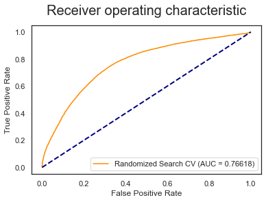

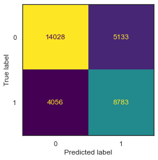

```python
y_hat_lg_m1 = search_lr.predict(X_test)
get_classification_report(X_train, y_train, X_test, y_test, y_hat_lg_m1, search_lr)
```

```python
best_cutoff_m1, best_score_m1 = find_best_prob(search_lr, X_test, y_test)
```

**Plot New Confusion Matrix with best cut off that minimize loss of money**

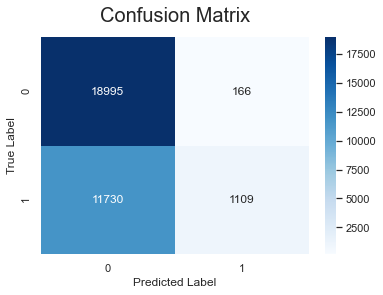

```python
y_hat_lg_m1_best_cutoff = (search_lr.predict_proba(X_test)[:,1]>best_cutoff_m1).astype("int32")
get_confusion_matrix(y_test,y_hat_lg_m1_best_cutoff)
```

```python
print(f"Best Normalized Score for m1 using Logistic Regression is: {best_score_m1}")
```

```
Best Normalized Score for m1 using Logistic Regression is: 9.6828125
```

#### Logistic Regression with interaction terms - Model 2

```python
params_lr = {
    "model__penalty": ["l2"],
    "model__C": [0.01, 0.1, 1, 10, 100],
    "model__solver": ["lbfgs","liblinear","saga"],
}
```

```python
# Define preprocessing for columns

categorical_pipe = Pipeline(steps=[("cat_impute", SimpleImputer(missing_values=np.nan, strategy='most_frequent')),
                                     ('cat', OneHotEncoder(handle_unknown='ignore'))])
numeric_pipe = Pipeline(steps=[('numeric_impute', SimpleImputer(missing_values=np.nan, strategy='mean')) ])

t_slr_impute = [
    ('cat', categorical_pipe, categorical_col),
    ('numeric', numeric_pipe, numeric_col)]

col_transform = ColumnTransformer(t_slr_impute)

interactions_pipe = Pipeline(steps=[(('interactions', PolynomialFeatures(degree=2, interaction_only=True,include_bias = False)))])
```

```python
%%time
# Using Default balanced setting
model_lr = LogisticRegression(C=1.0, class_weight='balanced',random_state=101,max_iter=10000)


pipeline_lr_m3 = Pipeline(steps=[('preprocessing',col_transform),
                                 ('interactions', interactions_pipe),
                                 ('scale',MinMaxScaler()),
                                 ('model', model_lr)])



clf_lr = GridSearchCV(pipeline_lr_m3, params_lr, cv=cv, scoring="roc_auc",
                     n_jobs=4, verbose=verbose, return_train_score=True)

search_lr = clf_lr.fit(X_train, y_train)
```

```
Fitting 10 folds for each of 15 candidates, totalling 150 fits
CPU times: user 12min 54s, sys: 45.3 s, total: 13min 39s
Wall time: 5d 10h 39min 20s
```

```python
file_name_lri = f"{cwd}/lr_model_interactions.sav"
#joblib.dump(search_lr, file_name_lri)
search_lr = joblib.load(file_name_lri)
```

```python
search_lr.best_estimator_.named_steps['interactions']
```

```
Pipeline(steps=[('interactions',
                 PolynomialFeatures(include_bias=False,
                                    interaction_only=True))])
```

```python
# number of features out
search_lr.best_estimator_.named_steps['interactions'].named_steps['interactions'].n_output_features_
```

```
2926
```

```python
# Get cross validation result
search_columns_m2 = ["param_model__C",'param_model__solver',"mean_train_score",
                    "mean_test_score","mean_fit_time","rank_test_score"]
df_search_result_m2 = cv_summary(search_lr,search_columns_m2)
df_search_result_m2
```

|  | param_combination | param_model__C | param_model__solver | mean_train_score | mean_validation_score | mean_fit_time | rank_validation_score |
| --- | --- | --- | --- | --- | --- | --- | --- |
| 0 | 1 | 0.01 | lbfgs | 0.907509 | 0.904347 | 634.000444 | 15 |
| 1 | 2 | 0.01 | liblinear | 0.907515 | 0.904355 | 4174.694779 | 13 |
| 2 | 3 | 0.01 | saga | 0.907507 | 0.904348 | 535.809416 | 14 |
| 3 | 4 | 0.1 | lbfgs | 0.936634 | 0.932124 | 1049.417765 | 11 |
| 4 | 5 | 0.1 | liblinear | 0.936642 | 0.932126 | 9631.195834 | 10 |
| 5 | 6 | 0.1 | saga | 0.936617 | 0.932102 | 769.297478 | 12 |
| 6 | 7 | 1 | lbfgs | 0.945119 | 0.939664 | 2417.001324 | 8 |
| 7 | 8 | 1 | liblinear | 0.945133 | 0.939677 | 16008.036350 | 7 |
| 8 | 9 | 1 | saga | 0.945082 | 0.939651 | 3049.278712 | 9 |
| 9 | 10 | 10 | lbfgs | 0.946692 | 0.940392 | 4353.828537 | 3 |
| 10 | 11 | 10 | liblinear | 0.946719 | 0.940433 | 42929.030104 | 1 |
| 11 | 12 | 10 | saga | 0.946581 | 0.940395 | 9765.525877 | 2 |
| 12 | 13 | 100 | lbfgs | 0.947122 | 0.940185 | 6633.874342 | 5 |
| 13 | 14 | 100 | liblinear | 0.947208 | 0.940173 | 70360.364752 | 6 |
| 14 | 15 | 100 | saga | 0.946885 | 0.940324 | 13495.079161 | 4 |

```
Train accuracy: 0.94645
Test result:
Normalized Total Dollar Loss on Test Data 9.07891

              precision    recall  f1-score   support

           0       0.91      0.87      0.89     19161
           1       0.82      0.88      0.85     12839

    accuracy                           0.87     32000
   macro avg       0.87      0.87      0.87     32000
weighted avg       0.87      0.87      0.87     32000

Test AUC: 0.94129
```

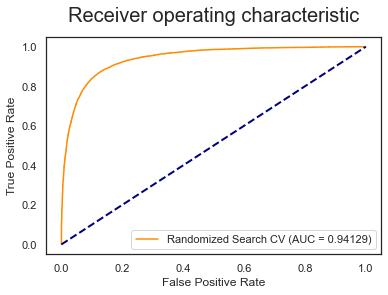

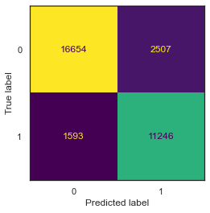

```python
y_hat_lg_m2 = search_lr.predict(X_test)
get_classification_report(X_train, y_train, X_test, y_test, y_hat_lg_m2, search_lr)
```

```python
best_cutoff_m2, best_score_m2 = find_best_prob(search_lr, X_test, y_test)
```

**Plot New Confusion Matrix with best cut off that minimize loss of money**

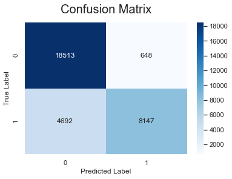

```python
y_hat_lg_m2_best_cutoff = (search_lr.predict_proba(X_test)[:,1]>best_cutoff_m2).astype("int32")
get_confusion_matrix(y_test,y_hat_lg_m2_best_cutoff)
```

```python
print(f"Best Normalized Score for m2 using Random Forest is: {best_score_m2}")
```

[output not shown]

#### Random Forest - Model 3

```python
params_rf = {
    "model__n_estimators": [250, 300, 350, 400],
    "model__max_features": ["auto"],
    "model__criterion": ['gini','entropy'],
    "model__max_depth":[10, 12, 15],
    "model__min_samples_split":[4, 7, 9],
    "model__class_weight":["balanced"]
}
```

```python
%%time

# Define preprocessing for columns
rfc = RandomForestClassifier(random_state=101)

rf_pipeline = Pipeline(steps=[('preprocessing',col_transform),('model',rfc)])

# Fit
clf_rfc = RandomizedSearchCV(rf_pipeline, params_rf, cv=cv, scoring='roc_auc', n_iter=15,
                      n_jobs=-2, verbose = 15, return_train_score=True,random_state=43)

search_rfc = clf_rfc.fit(X_train,y_train)
```

```
Fitting 10 folds for each of 15 candidates, totalling 150 fits
CPU times: user 4min 50s, sys: 5.25 s, total: 4min 55s
Wall time: 1h 17min
```

```python
file_name_rfc = f"{cwd}/rfc_model1.sav"
# joblib.dump(search_rfc, file_name_rfc)
search_rfc = joblib.load(file_name_rfc)
```

```python
# Get cross validation result
best_rfc_columns = ['param_model__n_estimators',"param_model__criterion","param_model__max_depth",
                    "param_model__min_samples_split","mean_train_score","mean_test_score","rank_test_score"]
df_best_rfc_cv_results = cv_summary(search_rfc, best_rfc_columns)
df_best_rfc_cv_results
```

|  | param_combination | param_model__n_estimators | param_model__criterion | param_model__max_depth | param_model__min_samples_split | mean_train_score | mean_validation_score | rank_validation_score |
| --- | --- | --- | --- | --- | --- | --- | --- | --- |
| 0 | 1 | 300 | entropy | 12 | 9 | 0.975415 | 0.955893 | 9 |
| 1 | 2 | 400 | entropy | 15 | 4 | 0.993705 | 0.966981 | 2 |
| 2 | 3 | 350 | entropy | 15 | 9 | 0.992213 | 0.966789 | 3 |
| 3 | 4 | 250 | entropy | 12 | 7 | 0.975976 | 0.955898 | 8 |
| 4 | 5 | 300 | gini | 12 | 4 | 0.977065 | 0.955836 | 11 |
| 5 | 6 | 400 | gini | 12 | 4 | 0.977063 | 0.955879 | 10 |
| 6 | 7 | 300 | gini | 10 | 7 | 0.957043 | 0.942202 | 14 |
| 7 | 8 | 350 | entropy | 15 | 4 | 0.993726 | 0.967004 | 1 |
| 8 | 9 | 250 | entropy | 10 | 9 | 0.956136 | 0.941868 | 15 |
| 9 | 10 | 350 | gini | 15 | 4 | 0.993645 | 0.966481 | 4 |
| 10 | 11 | 350 | gini | 10 | 7 | 0.957168 | 0.942339 | 12 |
| 11 | 12 | 300 | gini | 15 | 7 | 0.992679 | 0.966237 | 5 |
| 12 | 13 | 400 | gini | 12 | 7 | 0.976370 | 0.955963 | 7 |
| 13 | 14 | 400 | entropy | 10 | 4 | 0.956821 | 0.942211 | 13 |
| 14 | 15 | 350 | gini | 12 | 7 | 0.976399 | 0.956011 | 6 |

```
Train accuracy: 0.99278
Test result:
Normalized Total Dollar Loss on Test Data 5.66406

              precision    recall  f1-score   support

           0       0.92      0.92      0.92     19161
           1       0.89      0.89      0.89     12839

    accuracy                           0.91     32000
   macro avg       0.91      0.91      0.91     32000
weighted avg       0.91      0.91      0.91     32000

Test AUC: 0.96701
```

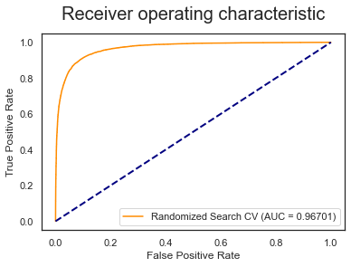

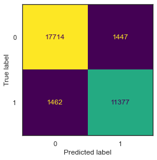

```python
y_hat_rfc = search_rfc.predict(X_test)
get_classification_report(X_train, y_train, X_test, y_test, y_hat_rfc, search_rfc)
```

```python
best_cutoff_m3, best_score_m3 = find_best_prob(search_rfc, X_test, y_test)
```

**Plot New Confusion Matrix with best cut off that minimize loss of money**

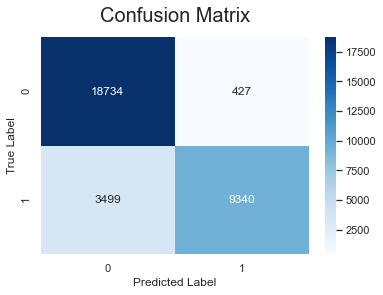

```python
y_hat_rf_m3_best_cutoff = (search_rfc.predict_proba(X_test)[:,1]>best_cutoff_m3).astype("int32")
get_confusion_matrix(y_test,y_hat_rf_m3_best_cutoff)
```

```python
print(f"Best Normalized Score for m3 using Random Forest is: {best_score_m3}")
```

```
Best Normalized Score for m3 using Random Forest is: 4.06796875
```

#### XGBoost - Model 4

```python
X_train_xg = col_transform.fit_transform(X_train)
X_test_xg = col_transform.transform(X_test)
```

```python
search_space = [
    {
        "model__learning_rate"    : [0.01, 0.1] ,
        "model__max_depth"        : [7, 8, 9],
        "model__subsample"        : [0.7, 0.9, 1],
        "model__gamma"            : [ 0.1, 0.4, 0.6],
     }
]
```

```python
%%time
model_xgb = xgb.XGBClassifier(
    n_estimators = 800,
    use_label_encoder =False,
    objective="binary:logistic",
    random_state=123,
)

# fit_params={"model__early_stopping_rounds": 10,
#             "model__eval_metric" : "auc",
#             "model__verbose":False,
#             "model__eval_set" : [[X_test_xg, y_test]]}

xgb_pipeline = Pipeline(steps=[('preprocessing',col_transform),
                               ('model',model_xgb)])

clf_xgb = RandomizedSearchCV(xgb_pipeline,search_space,cv=cv, scoring='roc_auc',n_iter=10,
                      n_jobs=-2, verbose = 20, return_train_score=True, random_state=102)

search_clf_xgb = clf_xgb.fit(X_train, y_train)
```

```
Fitting 10 folds for each of 10 candidates, totalling 100 fits
[05:08:32] WARNING: /Users/travis/build/dmlc/xgboost/src/learner.cc:1095: Starting in XGBoost 1.3.0, the default evaluation metric used with the objective 'binary:logistic' was changed from 'error' to 'logloss'. Explicitly set eval_metric if you'd like to restore the old behavior.
CPU times: user 1h 5min 15s, sys: 9.92 s, total: 1h 5min 25s
Wall time: 4h 58min 8s
```

```python
file_name_xgb = f"xgb_model1.sav"
#joblib.dump(search_clf_xgb, file_name_xgb)
search_clf_xgb = joblib.load(file_name_xgb)
```

```python
# Get cross validation result
best_xgb_columns = ["param_model__learning_rate","param_model__max_depth",
                    "param_model__subsample","param_model__gamma","mean_train_score",
                    "mean_test_score","rank_test_score"]
df_best_xgb_cv_results = cv_summary(search_clf_xgb, best_xgb_columns)
df_best_xgb_cv_results
```

|  | param_combination | param_model__learning_rate | param_model__max_depth | param_model__subsample | param_model__gamma | mean_train_score | mean_validation_score | rank_validation_score |
| --- | --- | --- | --- | --- | --- | --- | --- | --- |
| 0 | 1 | 0.01 | 8 | 0.7 | 0.6 | 0.986307 | 0.976183 | 6 |
| 1 | 2 | 0.01 | 8 | 1 | 0.4 | 0.986092 | 0.974887 | 8 |
| 2 | 3 | 0.1 | 8 | 0.7 | 0.4 | 1.000000 | 0.982530 | 5 |
| 3 | 4 | 0.01 | 7 | 1 | 0.4 | 0.979136 | 0.969644 | 10 |
| 4 | 5 | 0.1 | 8 | 0.9 | 0.4 | 0.999999 | 0.983041 | 4 |
| 5 | 6 | 0.01 | 7 | 0.9 | 0.1 | 0.979499 | 0.970428 | 9 |
| 6 | 7 | 0.01 | 8 | 0.7 | 0.4 | 0.986308 | 0.976151 | 7 |
| 7 | 8 | 0.1 | 8 | 0.9 | 0.1 | 1.000000 | 0.983099 | 3 |
| 8 | 9 | 0.1 | 9 | 1 | 0.4 | 1.000000 | 0.984205 | 1 |
| 9 | 10 | 0.1 | 8 | 0.9 | 0.6 | 0.999999 | 0.983147 | 2 |

```
Train accuracy: 1.00000
Test result:
Normalized Total Dollar Loss on Test Data 3.21172

              precision    recall  f1-score   support

           0       0.95      0.96      0.96     19161
           1       0.94      0.93      0.93     12839

    accuracy                           0.95     32000
   macro avg       0.94      0.94      0.94     32000
weighted avg       0.95      0.95      0.95     32000

Test AUC: 0.98450
```

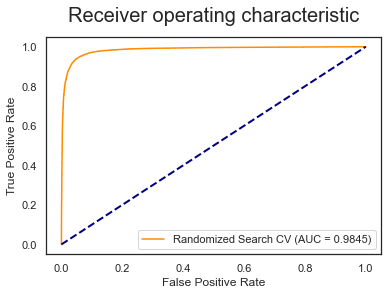

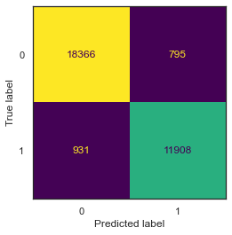

```python
y_hat_xgb = search_clf_xgb.predict(X_test)
get_classification_report(X_train, y_train, X_test, y_test, y_hat_xgb, search_clf_xgb)
```

```python
best_cutoff_m4, best_score_m4 = find_best_prob(search_clf_xgb, X_test, y_test)
```

**Plot New Confusion Matrix with best cut off that minimize loss of money**

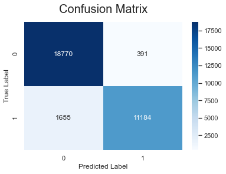

```python
y_hat_xgb_m4_best_cutoff = (search_clf_xgb.predict_proba(X_test)[:,1]>best_cutoff_m4).astype("int32")
get_confusion_matrix(y_test,y_hat_xgb_m4_best_cutoff)
```

```python
print(f"Best Normalized Score for m4 using XGBoost is: {best_score_m4}")
```

```
Best Normalized Score for m4 using XGBoost is: 2.51484375
```

#### Neural Network - Model 5

```python
X_train_nn = col_transform.fit_transform(X_train)
X_test_nn = col_transform.transform(X_test)
```

```python
X_train_nn.shape
```

```
(128000, 76)
```

```python
# Build Sequential NN model using Tensorflow and Keras
model = Sequential()
model.add(InputLayer(input_shape=(76,)))
model.add(Dense(units=250,activation='relu'))
model.add(Dropout(0.2))
model.add(Dense(units=200,activation='relu'))
model.add(Dropout(0.2))
model.add(Dense(units=100,activation='relu'))
model.add(Dropout(0.2))
model.add(Dense(units=1,activation='sigmoid'))

# Compile model
model.compile(loss='binary_crossentropy',
                  optimizer=keras.optimizers.Adam(learning_rate=0.001),
                  metrics=['accuracy', tf.keras.metrics.AUC()])

# Set early stopping variable
early_stop = EarlyStopping(monitor='val_loss', mode='min', patience=10)
```

```python
model.summary()
```

```
Model: "sequential"
_________________________________________________________________
Layer (type)                 Output Shape              Param #
=================================================================
dense (Dense)                (None, 250)               19250
_________________________________________________________________
dropout (Dropout)            (None, 250)               0
_________________________________________________________________
dense_1 (Dense)              (None, 200)               50200
_________________________________________________________________
dropout_1 (Dropout)          (None, 200)               0
_________________________________________________________________
dense_2 (Dense)              (None, 100)               20100
_________________________________________________________________
dropout_2 (Dropout)          (None, 100)               0
_________________________________________________________________
dense_3 (Dense)              (None, 1)                 101
=================================================================
Total params: 89,651
Trainable params: 89,651
Non-trainable params: 0
_________________________________________________________________
```

```python
%%time
model.fit(x=X_train_nn,
          y=y_train,
          batch_size=1000,
          epochs=2000,
          validation_data=(X_test_nn, y_test),
          callbacks=[early_stop]
          )
```

```
CPU times: user 6min 30s, sys: 2min 34s, total: 9min 5s
Wall time: 1min 56s
```

```
<tensorflow.python.keras.callbacks.History at 0x7f8dce2201c0>
```

```python
model_loss = pd.DataFrame(model.history.history)
```

```python
# Saving Train/Test loss history
file_name_model_history = "train_test_history_m5_v2.sav"
#joblib.dump(model_loss, file_name_model_history)
model_loss = joblib.load(file_name_model_history)
```

[output not shown]

```python
path = cwd+"/keras_model5_v2"
#model.save(path)
model = keras.models.load_model(path)
```

[output not shown]

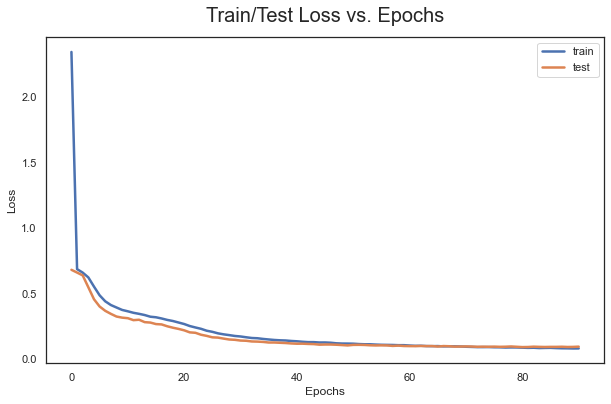

```python
plot_early_stop_rounds(model_loss)
```

```
Test result:
Normalized Total Dollar Loss on Test Data 1.83438

              precision    recall  f1-score   support

           0       0.97      0.98      0.98     19161
           1       0.96      0.96      0.96     12839

    accuracy                           0.97     32000
   macro avg       0.97      0.97      0.97     32000
weighted avg       0.97      0.97      0.97     32000

Test AUC: 0.99161
```

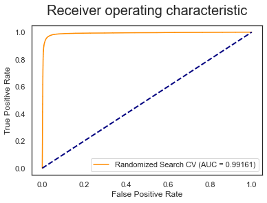

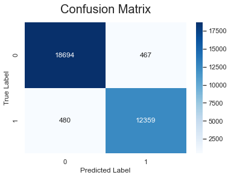

```python
predictions = (model.predict(X_test_nn)>0.5).astype("int32")
get_classification_report(X_train_nn,y_train,X_test_nn,y_test,predictions, model, nn_model=True)
```

```python
best_cutoff_m5, best_score_m5 = find_best_prob(model, X_test_nn, y_test, nn_model=True)
```

**Plot New Confusion Matrix with best cut off that minimize loss of money**

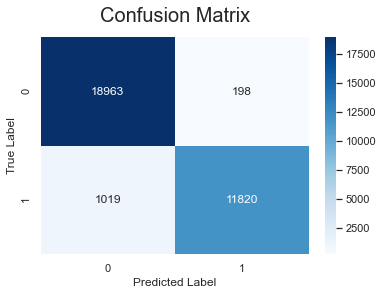

```python
y_hat_nn_m5_best_cutoff = (model.predict(X_test_nn)>best_cutoff_m5).astype("int32")
get_confusion_matrix(y_test,y_hat_nn_m5_best_cutoff)
```

```python
print(f"Best Normalized Score for m5 using Deep Neural Network is: {best_score_m5}")
```

```
Best Normalized Score for m5 using Deep Neural Network is: 1.41484375
```

#### Ensemble - Model 6

```python
# Build pipeline for Logistic Regression for Ensemble
# Using previous discovered best parameters
pipeline_m6_lr = Pipeline(steps=[('preprocessing',col_transform),
                                ('model', LogisticRegression(C=100, solver='lbfgs',random_state=101,
                                                            max_iter=10000, class_weight='balanced'))])
```

```python
# Build pipeline for Random Forest for Ensemble
# Using previous discovered best parameters
pipeline_m6_rf = Pipeline(steps=[('preprocessing',col_transform),
                              ('model',RandomForestClassifier(
                                  n_estimators=350, criterion='entropy', max_depth=15,
                                  min_samples_split=4,
                                  random_state=101,n_jobs=-2))])
```

```python
# Build pipeline for XGBoost for Ensemble
# Using previous discovered best parameters
model_xgb_m6 = xgb.XGBClassifier(
    n_estimators = 800, learning_rate = 0.1,
    max_depth = 9, subsample = 1,
    gamma = 0.4, use_label_encoder =False,
    objective="binary:logistic", random_state=123
)
pipeline_m6_xgb = Pipeline(steps=[('preprocessing',col_transform),
                               ('model',model_xgb_m6)])
```

```python
from numpy import hstack
from sklearn.model_selection import cross_val_predict, cross_val_score
```

```python
# Code ideas borrowed from: https://machinelearningmastery.com/blending-ensemble-machine-learning-with-python/
# get a list of base models
def get_models():
    models = list()
    models.append(('lr', pipeline_m6_lr))
    models.append(('rf', pipeline_m6_rf))
    models.append(('xgb', pipeline_m6_xgb))
    return models

# fit the ensemble
def fit_ensemble(models, X_train, y_train, cv = 5):
    # fit all models on the training set and use cross validation predict
    # to get prediction score for ensemble
    meta_X = list()
    for name, model in models:
        # get cross validation score
        print("Current processing: ", name)
        model.fit(X_train, y_train)
        preds_prob = cross_val_predict(model, X_train, y_train, verbose=15,
                                       cv = cv, method='predict_proba',n_jobs=-2)
        # store predictions as input for ensembling
        meta_X.append(preds_prob)
    # create 2d array from predictions, each set is an input feature
    meta_X = hstack(meta_X)
    # define 2nd level ensemble model
    level2_ensemble = LogisticRegression()
    # fit on predictions from base models
    level2_ensemble.fit(meta_X, y_train)
    return level2_ensemble

# make a prediction with the ensemble models
def predict_ensemble(models, level2_ensemble, X_test):
    # make predictions with base models
    meta_X = list()
    for name, model in models:
        # predict with base model
        yhat = model.predict_proba(X_test)
        # store prediction
        meta_X.append(yhat)
    # create 2d array from predictions, each set is an input feature
    meta_X = hstack(meta_X)
    # predict
    return level2_ensemble.predict_proba(meta_X)
```

```python
# Initialize models
ensemble_models = get_models()
```

```python
%%time
# Get Level2 ensemble model
level2_ensemble = fit_ensemble(ensemble_models, X_train, y_train, cv=10)
```

```
Current processing:  lr
```

```
[Parallel(n_jobs=-2)]: Using backend LokyBackend with 15 concurrent workers.
[Parallel(n_jobs=-2)]: Done   1 tasks      | elapsed:   15.7s
[Parallel(n_jobs=-2)]: Done   2 out of  10 | elapsed:   25.4s remaining:  1.7min
[Parallel(n_jobs=-2)]: Done   3 out of  10 | elapsed:   26.1s remaining:  1.0min
[Parallel(n_jobs=-2)]: Done   4 out of  10 | elapsed:   26.2s remaining:   39.3s
[Parallel(n_jobs=-2)]: Done   5 out of  10 | elapsed:   26.4s remaining:   26.4s
[Parallel(n_jobs=-2)]: Done   6 out of  10 | elapsed:   27.4s remaining:   18.3s
[Parallel(n_jobs=-2)]: Done   7 out of  10 | elapsed:   28.0s remaining:   12.0s
[Parallel(n_jobs=-2)]: Done   8 out of  10 | elapsed:   28.2s remaining:    7.1s
[Parallel(n_jobs=-2)]: Done  10 out of  10 | elapsed:   30.5s remaining:    0.0s
[Parallel(n_jobs=-2)]: Done  10 out of  10 | elapsed:   30.5s finished
```

```
Current processing:  rf
```

```
[Parallel(n_jobs=-2)]: Using backend LokyBackend with 15 concurrent workers.
[Parallel(n_jobs=-2)]: Done   1 tasks      | elapsed:  5.3min
[Parallel(n_jobs=-2)]: Done   2 out of  10 | elapsed:  5.3min remaining: 21.4min
[Parallel(n_jobs=-2)]: Done   3 out of  10 | elapsed:  5.3min remaining: 12.5min
[Parallel(n_jobs=-2)]: Done   4 out of  10 | elapsed:  5.3min remaining:  8.0min
[Parallel(n_jobs=-2)]: Done   5 out of  10 | elapsed:  5.4min remaining:  5.4min
[Parallel(n_jobs=-2)]: Done   6 out of  10 | elapsed:  5.4min remaining:  3.6min
[Parallel(n_jobs=-2)]: Done   7 out of  10 | elapsed:  5.4min remaining:  2.3min
[Parallel(n_jobs=-2)]: Done   8 out of  10 | elapsed:  5.4min remaining:  1.3min
[Parallel(n_jobs=-2)]: Done  10 out of  10 | elapsed:  5.4min remaining:    0.0s
[Parallel(n_jobs=-2)]: Done  10 out of  10 | elapsed:  5.4min finished
```

```
Current processing:  xgb
[17:50:22] WARNING: /Users/travis/build/dmlc/xgboost/src/learner.cc:1095: Starting in XGBoost 1.3.0, the default evaluation metric used with the objective 'binary:logistic' was changed from 'error' to 'logloss'. Explicitly set eval_metric if you'd like to restore the old behavior.
```

```
[Parallel(n_jobs=-2)]: Using backend LokyBackend with 15 concurrent workers.
[Parallel(n_jobs=-2)]: Done   1 tasks      | elapsed: 39.0min
[Parallel(n_jobs=-2)]: Done   2 out of  10 | elapsed: 39.1min remaining: 156.5min
[Parallel(n_jobs=-2)]: Done   3 out of  10 | elapsed: 39.2min remaining: 91.4min
[Parallel(n_jobs=-2)]: Done   4 out of  10 | elapsed: 39.3min remaining: 59.0min
[Parallel(n_jobs=-2)]: Done   5 out of  10 | elapsed: 39.3min remaining: 39.3min
[Parallel(n_jobs=-2)]: Done   6 out of  10 | elapsed: 39.4min remaining: 26.3min
[Parallel(n_jobs=-2)]: Done   7 out of  10 | elapsed: 39.4min remaining: 16.9min
[Parallel(n_jobs=-2)]: Done   8 out of  10 | elapsed: 39.4min remaining:  9.9min
[Parallel(n_jobs=-2)]: Done  10 out of  10 | elapsed: 39.5min remaining:    0.0s
[Parallel(n_jobs=-2)]: Done  10 out of  10 | elapsed: 39.5min finished
```

```
CPU times: user 1h 16min 58s, sys: 31 s, total: 1h 17min 29s
Wall time: 50min 28s
```

```python
# Running prediction probability results
pred_probs = predict_ensemble(ensemble_models,level2_ensemble,X_test)
```

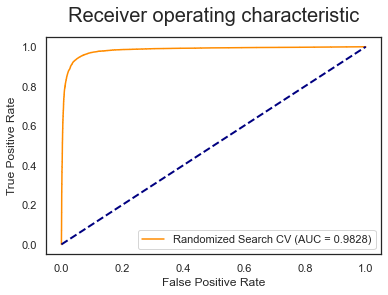

```python
plot_roc_curve_custom(X_test, y_test, pred_probs, probability=True)
```

**Plot New Confusion Matrix with best cut off that minimize loss of money**

```python
best_cutoff_m6, best_score_m6 = find_best_prob(pred_probs, X_test, y_test, probability=True)
```

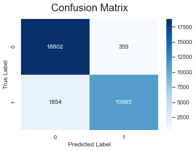

```python
y_hat_ensemble_m6_best_cutoff = (pred_probs[:,1]>best_cutoff_m6).astype("int32")
get_confusion_matrix(y_test,y_hat_ensemble_m6_best_cutoff)
```

```python
print(f"Best Normalized Score for m6 using ensemble is: {best_score_m6}")
```

```
Best Normalized Score for m6 using ensemble is: 2.5703125
```

```python
file_name_ensemble_level1 = f"{cwd}/ensemble_model_level1.sav"
#joblib.dump(ensemble_models, file_name_ensemble_level1)

file_name_ensemble_level2 = f"{cwd}/ensemble_model_level2.sav"
#joblib.dump(level2_ensemble, file_name_ensemble_level2)

ensemble_models = joblib.load(file_name_ensemble_level1)
level2_ensemble = joblib.load(file_name_ensemble_level2)
```